# Notebook 3: Greenwashing Analysis of Real Reports

**Author:** Maxim G.V. (@builtbymaxim)

## Overview

This notebook applies our fine-tuned greenwashing detection model to real-world annual reports from asset managers.

## Pipeline

1. Load fine-tuned RoBERTa model
2. Process PDF reports (extract text, section into relevant chapters)
3. Calculate hybrid scores:
   - VUI (Vagueness Index) - rule-based hedging word detection
   - SPI (Specificity Index) - AI + rule-based concrete claim detection
   - GW (Greenwashing Risk) - combined metric
4. Visualize and analyze results

## Companies Analyzed

BlackRock, Amundi, DWS, Schroders, State Street, KKR, Blackstone, CITIC (2021-2024)

## Import & Setup

```python
import sys
import os
import torch
import yaml
import pandas as pd
import numpy as np
import matplotlib.pyplot as plt
import seaborn as sns
from transformers import pipeline
from tqdm.notebook import tqdm

# Add src directory to path
sys.path.append(os.path.abspath(".."))

# Import custom modules from thesis code
from src.parsing import extract_pages, split_sentences
from src.sectioning import section_by_headings, collect_section_sentences
from src.vui import compute_vui
from src.spi import compute_spi_rule

# Load configuration
with open("../config.yml", "r") as f:
    cfg = yaml.safe_load(f)

# Set plotting style
sns.set_style("whitegrid")
plt.rcParams['figure.figsize'] = (12, 8)

print("Libraries loaded successfully.")
```

```
Libraries loaded successfully.
```

## Load Fine-Tuned Model

```python
from transformers import AutoTokenizer, AutoModelForSequenceClassification
import torch

MODEL_PATH = "../models/gw_finetuned"

# Load tokenizer and model separately for better control
tokenizer = AutoTokenizer.from_pretrained(MODEL_PATH)
model = AutoModelForSequenceClassification.from_pretrained(MODEL_PATH)

# Move model to device
device = torch.device("cuda" if torch.cuda.is_available() else "cpu")
model = model.to(device)
model.eval()

def classify_texts(texts, batch_size=16):
    """
    Classify texts with proper truncation handling.
    Returns list of predictions with label and score.
    """
    results = []

    for i in range(0, len(texts), batch_size):
        batch = texts[i:i+batch_size]

        # Tokenize with truncation
        inputs = tokenizer(
            batch,
            padding=True,
            truncation=True,
            max_length=128,
            return_tensors="pt"
        ).to(device)

        # Get predictions
        with torch.no_grad():
            outputs = model(**inputs)
            predictions = torch.nn.functional.softmax(outputs.logits, dim=-1)
            pred_labels = predictions.argmax(dim=-1).cpu().numpy()
            pred_scores = predictions.max(dim=-1).values.cpu().numpy()

        # Format results
        for label, score in zip(pred_labels, pred_scores):
            results.append({
                "label": f"LABEL_{label}",
                "score": float(score)
            })

    return results

print(f"Model loaded from: {MODEL_PATH}")
print(f"Device: {device}")
print("Ready for inference.")
```

```
Model loaded from: ../models/gw_finetuned
Device: cpu
Ready for inference.
```

## Model Validation

Test the model on sample sentences to verify it works correctly.

```python
print("="*60)
print("MODEL VALIDATION ON SAMPLE SENTENCES")
print("="*60)

# Test sentences
test_sentences = [
    "We reduced emissions by 42% compared to 2020 baseline.",
    "We are committed to environmental sustainability.",
    "Our fund targets net-zero by 2050.",
    "Installed 500 solar panels generating 2.3 GWh annually.",
    "We aim to enhance our ESG practices over time."
]

predictions = classify_texts(test_sentences)

for sent, pred in zip(test_sentences, predictions):
    label = "SPECIFIC" if pred['label'] == 'LABEL_1' else "VAGUE"
    confidence = pred['score']
    print(f"\n[{label}] (confidence: {confidence:.2%})")
    print(f"  {sent}")

print("\nValidation complete. Model is working as expected.")
```

```
============================================================
MODEL VALIDATION ON SAMPLE SENTENCES
============================================================

[SPECIFIC] (confidence: 99.94%)
  We reduced emissions by 42% compared to 2020 baseline.

[VAGUE] (confidence: 99.95%)
  We are committed to environmental sustainability.

[SPECIFIC] (confidence: 99.91%)
  Our fund targets net-zero by 2050.

[SPECIFIC] (confidence: 99.94%)
  Installed 500 solar panels generating 2.3 GWh annually.

[VAGUE] (confidence: 99.94%)
  We aim to enhance our ESG practices over time.

Validation complete. Model is working as expected.
```

## Find PDF Reports

```python
input_dir = "../inputs"

# Get all PDF files
pdf_files = sorted([f for f in os.listdir(input_dir) if f.endswith(".pdf")])

print(f"Found {len(pdf_files)} reports to analyze:")
for pdf in pdf_files:
    print(f"  - {pdf}")
```

```
Found 31 reports to analyze:
  - KKR-2021.pdf
  - KKR-2022.pdf
  - KKR-2023.pdf
  - KKR-2024.pdf
  - amundi-2021.pdf
  - amundi-2022.pdf
  - amundi-2023.pdf
  - amundi-2024.pdf
  - blackrock-2021.pdf
  - blackrock-2022.pdf
  - blackrock-2023.pdf
  - blackstone-2021.pdf
  - blackstone-2022.pdf
  - blackstone-2023.pdf
  - blackstone-2024.pdf
  - citic-2021.pdf
  - citic-2022.pdf
  - citic-2023.pdf
  - citic-2024.pdf
  - dws-2021.pdf
  - dws-2022.pdf
  - dws-2023.pdf
  - dws-2024.pdf
  - schroders-2021.pdf
  - schroders-2022.pdf
  - schroders-2023.pdf
  - schroders-2024.pdf
  - state-street-2021.pdf
  - state-street-2022.pdf
  - state-street-2023.pdf
  - state-street-2024.pdf
```

## Main Processing Loop

Process each PDF report through the full pipeline.

```python
all_report_scores = []

print(f"Starting analysis of {len(pdf_files)} reports...")

for pdf_file in tqdm(pdf_files, desc="Processing Reports"):

    # Extract metadata from filename
    try:
        filename_clean = pdf_file.replace(".pdf", "")
        parts = filename_clean.split("-")
        year = int(parts[-1])
        issuer = parts[0].capitalize()
    except:
        print(f"Could not parse filename '{pdf_file}'. Using defaults.")
        year = 2023
        issuer = filename_clean

    # Parse PDF text
    pdf_path = os.path.join(input_dir, pdf_file)
    try:
        pages = extract_pages(pdf_path)
    except Exception as e:
        print(f"Error reading {pdf_file}: {e}")
        continue

    # Section the document
    buckets = section_by_headings(pages, cfg)
    target_sections = cfg["sectioning"]["target_sections"]

    # Collect sentences from relevant sections
    all_sentences = []
    for sec in target_sections:
        sec_pages = buckets.get(sec, [])
        if sec_pages:
            sents = collect_section_sentences(
                sec_pages,
                lambda txt: split_sentences(txt, "en_core_web_sm")
            )
            all_sentences.extend(sents)

    if not all_sentences:
        print(f"{pdf_file}: No text found in target sections. Skipping.")
        continue

    # Calculate VUI (Vagueness Index) using rule-based approach
    vui_res = compute_vui(all_sentences, cfg)
    vui_score = vui_res["vui_norm"]

    # Calculate SPI (Specificity Index) - Hybrid approach
    # Part 1: Rule-based (numbers, dates, units)
    spi_res = compute_spi_rule(all_sentences, cfg)

    # Part 2: AI-based (fine-tuned model)
    texts = [s["text"] for s in all_sentences]
    preds = classify_texts(texts)
    count_specific = sum(1 for p in preds if p["label"] == "LABEL_1")
    ai_spi_score = count_specific / len(all_sentences)

    # Combine rule-based and AI-based SPI (60/40 split)
    spi_hybrid = (0.6 * spi_res["spi_rule"]) + (0.4 * ai_spi_score)

    # Calculate final Greenwashing Risk Score
    # Formula: High vagueness + Low specificity = High risk
    gw_score = (0.56 * vui_score) + (0.44 * (1 - spi_hybrid))

    # Store results
    all_report_scores.append({
        "Issuer": issuer,
        "Year": year,
        "Filename": pdf_file,
        "VUI_Score": round(vui_score, 3),
        "SPI_Score": round(spi_hybrid, 3),
        "GW_Risk_Score": round(gw_score, 3),
        "Sentence_Count": len(all_sentences)
    })

print(f"\nProcessing complete. Analyzed {len(all_report_scores)} reports successfully.")
```

```
Starting analysis of 31 reports...
```

[output not shown]

[output not shown]

[output cut: 148 more lines]

[output not shown]

```
Processing complete. Analyzed 31 reports successfully.
```

## Results Table

```python
# Create DataFrame
results_df = pd.DataFrame(all_report_scores)
results_df = results_df.sort_values(['Issuer', 'Year'])

print("="*60)
print("GREENWASHING RISK SCORES BY COMPANY")
print("="*60)
display(results_df)

# Save results
output_path = "../outputs/greenwashing_scores.csv"
results_df.to_csv(output_path, index=False)
print(f"\nResults saved to: {output_path}")
```

```
============================================================
GREENWASHING RISK SCORES BY COMPANY
============================================================
```

|  | Issuer | Year | Filename | VUI_Score | SPI_Score | GW_Risk_Score | Sentence_Count |
| --- | --- | --- | --- | --- | --- | --- | --- |
| 4 | Amundi | 2021 | amundi-2021.pdf | 0.365 | 0.433 | 0.454 | 2992 |
| 5 | Amundi | 2022 | amundi-2022.pdf | 0.350 | 0.416 | 0.453 | 3265 |
| 6 | Amundi | 2023 | amundi-2023.pdf | 0.369 | 0.419 | 0.462 | 3471 |
| 7 | Amundi | 2024 | amundi-2024.pdf | 0.406 | 0.397 | 0.492 | 4309 |
| 8 | Blackrock | 2021 | blackrock-2021.pdf | 0.857 | 0.188 | 0.837 | 571 |
| 9 | Blackrock | 2022 | blackrock-2022.pdf | 0.856 | 0.194 | 0.834 | 708 |
| 10 | Blackrock | 2023 | blackrock-2023.pdf | 0.847 | 0.195 | 0.829 | 742 |
| 11 | Blackstone | 2021 | blackstone-2021.pdf | 0.406 | 0.357 | 0.510 | 1088 |
| 12 | Blackstone | 2022 | blackstone-2022.pdf | 0.600 | 0.203 | 0.687 | 1134 |
| 13 | Blackstone | 2023 | blackstone-2023.pdf | 0.580 | 0.203 | 0.675 | 1075 |
| 14 | Blackstone | 2024 | blackstone-2024.pdf | 0.497 | 0.250 | 0.609 | 1174 |
| 15 | Citic | 2021 | citic-2021.pdf | 0.312 | 0.351 | 0.461 | 1622 |
| 16 | Citic | 2022 | citic-2022.pdf | 0.271 | 0.333 | 0.445 | 1817 |
| 17 | Citic | 2023 | citic-2023.pdf | 0.281 | 0.337 | 0.449 | 956 |
| 18 | Citic | 2024 | citic-2024.pdf | 0.311 | 0.305 | 0.480 | 1348 |
| 19 | Dws | 2021 | dws-2021.pdf | 0.364 | 0.280 | 0.521 | 3167 |
| 20 | Dws | 2022 | dws-2022.pdf | 0.055 | 0.472 | 0.263 | 1574 |
| 21 | Dws | 2023 | dws-2023.pdf | 0.490 | 0.249 | 0.605 | 2984 |
| 22 | Dws | 2024 | dws-2024.pdf | 0.508 | 0.223 | 0.626 | 3500 |
| 0 | Kkr | 2021 | KKR-2021.pdf | 0.683 | 0.225 | 0.724 | 2042 |
| 1 | Kkr | 2022 | KKR-2022.pdf | 0.674 | 0.276 | 0.696 | 2298 |
| 2 | Kkr | 2023 | KKR-2023.pdf | 0.692 | 0.274 | 0.707 | 2154 |
| 3 | Kkr | 2024 | KKR-2024.pdf | 0.701 | 0.279 | 0.710 | 2349 |
| 23 | Schroders | 2021 | schroders-2021.pdf | 0.396 | 0.290 | 0.534 | 3085 |
| 24 | Schroders | 2022 | schroders-2022.pdf | 0.375 | 0.278 | 0.528 | 2936 |
| 25 | Schroders | 2023 | schroders-2023.pdf | 0.357 | 0.288 | 0.513 | 3401 |
| 26 | Schroders | 2024 | schroders-2024.pdf | 0.407 | 0.283 | 0.544 | 3497 |
| 27 | State | 2021 | state-street-2021.pdf | 0.663 | 0.333 | 0.665 | 1899 |
| 28 | State | 2022 | state-street-2022.pdf | 0.682 | 0.331 | 0.676 | 1630 |
| 29 | State | 2023 | state-street-2023.pdf | 0.702 | 0.329 | 0.688 | 1526 |
| 30 | State | 2024 | state-street-2024.pdf | 0.661 | 0.323 | 0.668 | 1494 |

```
Results saved to: ../outputs/greenwashing_scores.csv
```

## Summary Statistics

```python
print("="*60)
print("SUMMARY STATISTICS")
print("="*60)

# Descriptive statistics
summary = results_df[['VUI_Score', 'SPI_Score', 'GW_Risk_Score']].describe()
print("\n", summary)

# Top and bottom performers
print("\n" + "-"*60)
print("LOWEST GREENWASHING RISK (Best Performers):")
print("-"*60)
best = results_df.nsmallest(5, 'GW_Risk_Score')[['Issuer', 'Year', 'GW_Risk_Score']]
print(best.to_string(index=False))

print("\n" + "-"*60)
print("HIGHEST GREENWASHING RISK (Worst Performers):")
print("-"*60)
worst = results_df.nlargest(5, 'GW_Risk_Score')[['Issuer', 'Year', 'GW_Risk_Score']]
print(worst.to_string(index=False))

# Average by company
print("\n" + "-"*60)
print("AVERAGE GREENWASHING RISK BY COMPANY (2021-2024):")
print("-"*60)
avg_by_company = results_df.groupby('Issuer')['GW_Risk_Score'].mean().sort_values()
for company, score in avg_by_company.items():
    print(f"{company:20s}: {score:.3f}")
```

```
============================================================
SUMMARY STATISTICS
============================================================

        VUI_Score  SPI_Score  GW_Risk_Score
count  31.000000  31.000000      31.000000
mean    0.507032   0.300452       0.591774
std     0.198004   0.075152       0.135165
min     0.055000   0.188000       0.263000
25%     0.364500   0.249500       0.486000
50%     0.490000   0.288000       0.605000
75%     0.678000   0.335000       0.687500
max     0.857000   0.472000       0.837000

------------------------------------------------------------
LOWEST GREENWASHING RISK (Best Performers):
------------------------------------------------------------
Issuer  Year  GW_Risk_Score
   Dws  2022          0.263
 Citic  2022          0.445
 Citic  2023          0.449
Amundi  2022          0.453
Amundi  2021          0.454

------------------------------------------------------------
HIGHEST GREENWASHING RISK (Worst Performers):
------------------------------------------------------------
   Issuer  Year  GW_Risk_Score
Blackrock  2021          0.837
Blackrock  2022          0.834
Blackrock  2023          0.829
      Kkr  2021          0.724
      Kkr  2024          0.710

------------------------------------------------------------
AVERAGE GREENWASHING RISK BY COMPANY (2021-2024):
------------------------------------------------------------
Citic               : 0.459
Amundi              : 0.465
Dws                 : 0.504
Schroders           : 0.530
Blackstone          : 0.620
State               : 0.674
Kkr                 : 0.709
Blackrock           : 0.833
```

## Visualizations

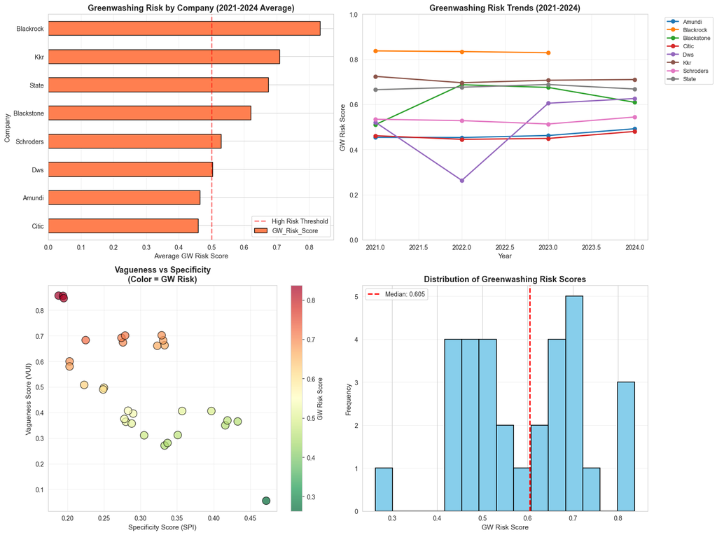

```
Visualization saved to: ../outputs/greenwashing_analysis.png
```

```python
fig, axes = plt.subplots(2, 2, figsize=(16, 12))

# 1. Average GW Risk by Company
ax1 = axes[0, 0]
avg_by_issuer = results_df.groupby('Issuer')['GW_Risk_Score'].mean().sort_values()
avg_by_issuer.plot(kind='barh', ax=ax1, color='coral', edgecolor='black')
ax1.set_xlabel('Average GW Risk Score', fontsize=11)
ax1.set_ylabel('Company', fontsize=11)
ax1.set_title('Greenwashing Risk by Company (2021-2024 Average)', fontsize=13, fontweight='bold')
ax1.axvline(x=0.5, color='red', linestyle='--', alpha=0.5, linewidth=2, label='High Risk Threshold')
ax1.legend()
ax1.grid(axis='x', alpha=0.3)

# 2. Trend over Time
ax2 = axes[0, 1]
for issuer in results_df['Issuer'].unique():
    issuer_data = results_df[results_df['Issuer'] == issuer].sort_values('Year')
    ax2.plot(issuer_data['Year'], issuer_data['GW_Risk_Score'],
             marker='o', linewidth=2, markersize=6, label=issuer)
ax2.set_xlabel('Year', fontsize=11)
ax2.set_ylabel('GW Risk Score', fontsize=11)
ax2.set_title('Greenwashing Risk Trends (2021-2024)', fontsize=13, fontweight='bold')
ax2.legend(bbox_to_anchor=(1.05, 1), loc='upper left', fontsize=9)
ax2.grid(True, alpha=0.3)
ax2.set_ylim([0, 1])

# 3. VUI vs SPI Scatter Plot
ax3 = axes[1, 0]
scatter = ax3.scatter(
    results_df['SPI_Score'],
    results_df['VUI_Score'],
    c=results_df['GW_Risk_Score'],
    cmap='RdYlGn_r',
    s=150,
    alpha=0.7,
    edgecolors='black',
    linewidth=1
)
ax3.set_xlabel('Specificity Score (SPI)', fontsize=11)
ax3.set_ylabel('Vagueness Score (VUI)', fontsize=11)
ax3.set_title('Vagueness vs Specificity\n(Color = GW Risk)', fontsize=13, fontweight='bold')
cbar = plt.colorbar(scatter, ax=ax3)
cbar.set_label('GW Risk Score', fontsize=10)
ax3.grid(True, alpha=0.3)

# 4. Distribution of GW Risk Scores
ax4 = axes[1, 1]
results_df['GW_Risk_Score'].hist(
    bins=15,
    ax=ax4,
    color='skyblue',
    edgecolor='black',
    linewidth=1.2
)
median_score = results_df['GW_Risk_Score'].median()
ax4.axvline(
    x=median_score,
    color='red',
    linestyle='--',
    linewidth=2,
    label=f"Median: {median_score:.3f}"
)
ax4.set_xlabel('GW Risk Score', fontsize=11)
ax4.set_ylabel('Frequency', fontsize=11)
ax4.set_title('Distribution of Greenwashing Risk Scores', fontsize=13, fontweight='bold')
ax4.legend(fontsize=10)
ax4.grid(axis='y', alpha=0.3)

plt.tight_layout()
viz_path = '../outputs/greenwashing_analysis.png'
plt.savefig(viz_path, dpi=300, bbox_inches='tight')
plt.show()

print(f"\nVisualization saved to: {viz_path}")
```

## Key Findings

Interpret the results and draw conclusions.

```python
print("="*60)
print("KEY FINDINGS")
print("="*60)

# Overall statistics
mean_gw = results_df['GW_Risk_Score'].mean()
median_gw = results_df['GW_Risk_Score'].median()
std_gw = results_df['GW_Risk_Score'].std()

print(f"\n1. OVERALL METRICS:")
print(f"   Mean GW Risk: {mean_gw:.3f}")
print(f"   Median GW Risk: {median_gw:.3f}")
print(f"   Std Dev: {std_gw:.3f}")

# High risk companies
high_risk = results_df[results_df['GW_Risk_Score'] > 0.6]
high_risk_pct = len(high_risk) / len(results_df) * 100

print(f"\n2. HIGH RISK CLASSIFICATION:")
print(f"   Reports with GW Risk > 0.6: {len(high_risk)} ({high_risk_pct:.1f}%)")
if len(high_risk) > 0:
    print(f"   Companies: {', '.join(high_risk['Issuer'].unique())}")

# Temporal trend
trend = results_df.groupby('Year')['GW_Risk_Score'].mean()
trend_direction = "DECREASING" if trend.iloc[-1] < trend.iloc[0] else "INCREASING"

print(f"\n3. TEMPORAL TREND:")
print(f"   Average GW Risk by year:")
for year, score in trend.items():
    print(f"     {year}: {score:.3f}")
print(f"   Overall trend: {trend_direction}")

# Component analysis
mean_vui = results_df['VUI_Score'].mean()
mean_spi = results_df['SPI_Score'].mean()

print(f"\n4. COMPONENT ANALYSIS:")
print(f"   Average Vagueness (VUI): {mean_vui:.3f}")
print(f"   Average Specificity (SPI): {mean_spi:.3f}")

dominant_factor = "Vagueness" if mean_vui > (1 - mean_spi) else "Lack of Specificity"
print(f"   Dominant risk factor: {dominant_factor}")
```

```
============================================================
KEY FINDINGS
============================================================

1. OVERALL METRICS:
   Mean GW Risk: 0.592
   Median GW Risk: 0.605
   Std Dev: 0.135

2. HIGH RISK CLASSIFICATION:
   Reports with GW Risk > 0.6: 16 (51.6%)
   Companies: Blackrock, Blackstone, Dws, Kkr, State

3. TEMPORAL TREND:
   Average GW Risk by year:
     2021: 0.588
     2022: 0.573
     2023: 0.616
     2024: 0.590
   Overall trend: INCREASING

4. COMPONENT ANALYSIS:
   Average Vagueness (VUI): 0.507
   Average Specificity (SPI): 0.300
   Dominant risk factor: Lack of Specificity
```

## Conclusion

This analysis demonstrates the application of a fine-tuned LLM for detecting greenwashing in corporate sustainability reports. The hybrid approach (combining rule-based NLP with AI classification) provides a quantitative measure of disclosure quality across multiple asset managers and years.

### Model Performance

- Successfully classified specific vs vague claims
- Hybrid scoring system captures both linguistic vagueness and lack of concrete commitments